# Projet Camille Schittly

J’ai utilisé ce type de R Markdown avec ce package qui est nécessaire.

```r
#install.packages("rmdformats")
```

# Exercice 1

# Question 1

Voici quelque définitions que l’on utlisera dans la suite.

On observe une série chronologique (appelée également série temporelle ou plus simplement chronique) si on observe une suite $\{x_t, t = 1, \ldots, T\}$ de réels où $t$ représente la date de la mesure d’une certaine quantité d’intérêt $Q$ et $x_t$ est la valeur de $Q$ à l’instant $t$.

Une série temporelle est dite stationnaire si ses propriétés statistiques ne changent pas avec le temps. Formellement, une série temporelle $x_t$ est stationnaire si elle satisfait les conditions suivantes : - La moyenne $\mu_t$ est constante pour tout $t$. - La variance $\sigma_t^2$ est constante pour tout $t$. - La covariance $\text{Cov}(y_t, y_{t+k})$ entre $x_t$ et $x_{t+k}$ ne dépend pas de $t$.

La tendance (ou trend) qui repr´esente l’évolution à long terme de la série. On la notera $T(t)$

La composante saisonnière qui est responsable des “pics” et des “creux” sur le graphique et qui correspond à un phénomène qui se répète à intervalles de temps réguliers On la notera $S(t;p)$ et elle périodique de période $p$

La composante d’erreur (ou de bruit) qui traduit des fluctuations aléatoires.

## Etude par heure

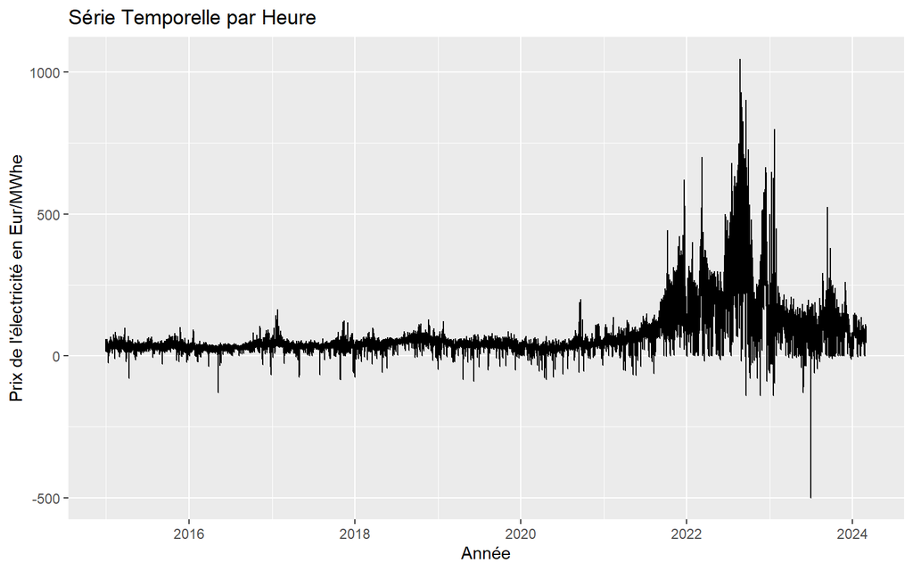

```r
library(tidyverse)
library(dplyr)

df =read_csv("Germany.csv", na = c(":"),show_col_types = FALSE)
df = df %>% rename("heuremond" = "Datetime (UTC)") %>% rename("heureloc" = "Datetime (Local)") %>% rename("Prix" = "Price (EUR/MWhe)") %>% mutate(date = as.Date(heuremond))


ggplot(data = df, aes(x = date, y = Prix)) +
  geom_line() +
  labs(title = "Série Temporelle par Heure",
       x = "Année",
       y = "Prix de l'électricité en Eur/MWhe")
```

Il y a 24 observations par jours.

### Tendance et saisonnalité

Afin d’estimer la tendance et la saisonnalitée nous pouvons utliser le code suivant

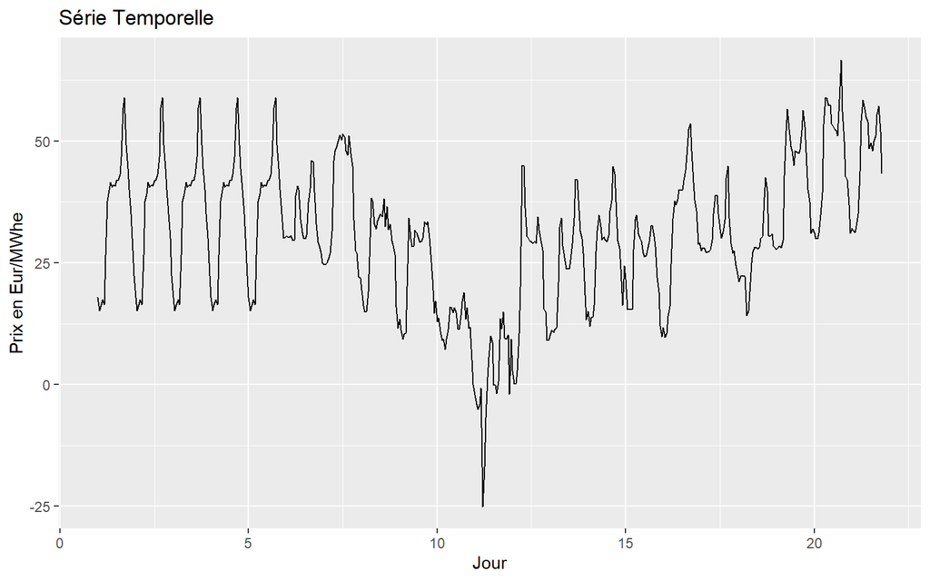

```r
Xh = ts(data = df$Prix[1:500], frequency = 24)
df1 <- data.frame(Date = time(Xh), Prix = as.numeric(Xh))

m = decompose(Xh)
ggplot(df1, aes(x = Date, y = Prix)) +
  geom_line() +
  labs(y = "Prix en Eur/MWhe", title = "Série Temporelle", x = "Jour")
```

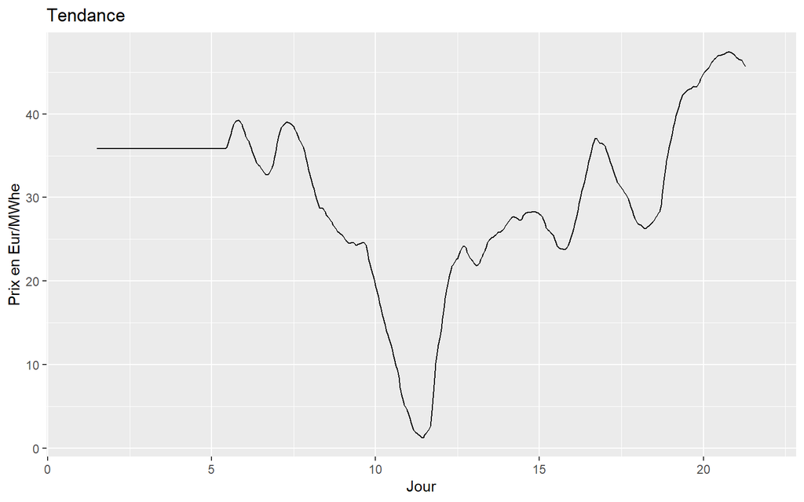

```r
df_trend <- data.frame(Date = time(m$trend), Prix = as.numeric(m$trend))
ggplot(df_trend, aes(x =Date, y = Prix)) +
  geom_line() +
  labs(y = "Prix en Eur/MWhe",title = "Tendance", x = "Jour")
```

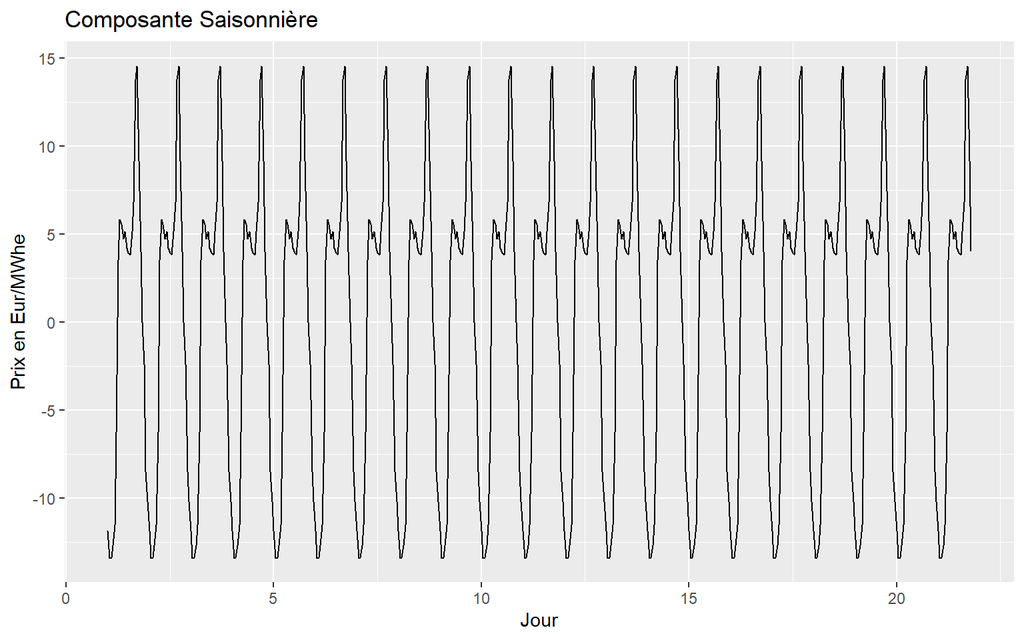

```r
df_seasonal <- data.frame(Date = time(m$seasonal), Prix = as.numeric(m$seasonal))
ggplot(df_seasonal, aes(x = Date, y = Prix)) +
  geom_line() +
  labs(y = "Prix en Eur/MWhe",title = "Composante Saisonnière", x = "Jour")
```

Ici je choisi une féquence de 24 comme il y a 24 données en heure dans la journée et je regarde le début de la série temporelle.

Ainsi sur l’axe des abscisses, chaque numéro correspond à un jour écoulé.

Pour cette partie on voit une tendance décroissante puis croissante

Pour la saisonnalité, c’est assez claire qu’il y en ai une, il y a des variations cyclique qui se répetent à des intérvalles réguliers, ces intervalle sont en fait les 24h d’une journée.

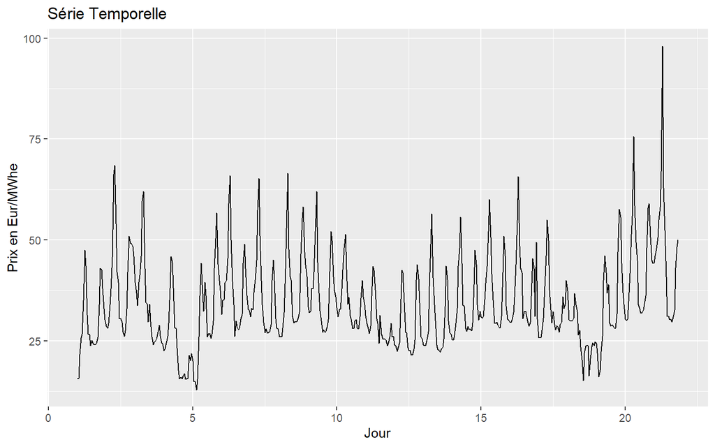

```r
Xh2 = ts(data = df$Prix[1500:2000], frequency = 24)
df2 <- data.frame(Date = time(Xh2), Prix = as.numeric(Xh2))
m = decompose(Xh2)

ggplot(df2, aes(x = Date, y = Prix)) +
  geom_line() +
  labs(title = "Série Temporelle", y = "Prix en Eur/MWhe", x = "Jour")
```

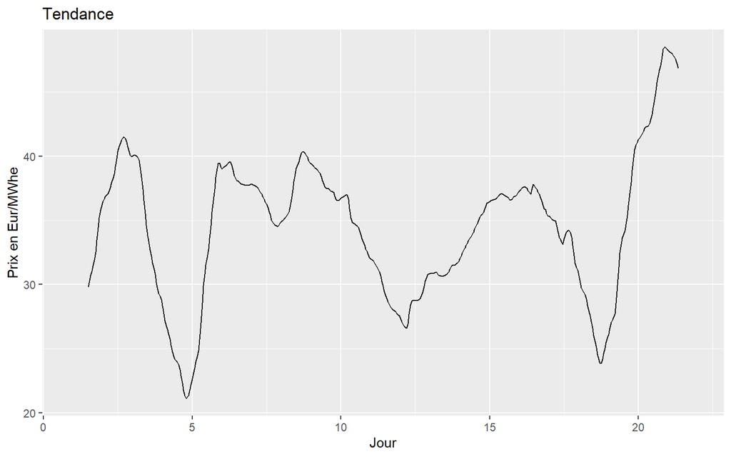

```r
df_trend <- data.frame(Date = time(m$trend), Prix = as.numeric(m$trend))
ggplot(df_trend, aes(x = Date, y = Prix)) +
  geom_line() +
  labs(title = "Tendance", y = "Prix en Eur/MWhe", x = "Jour")
```

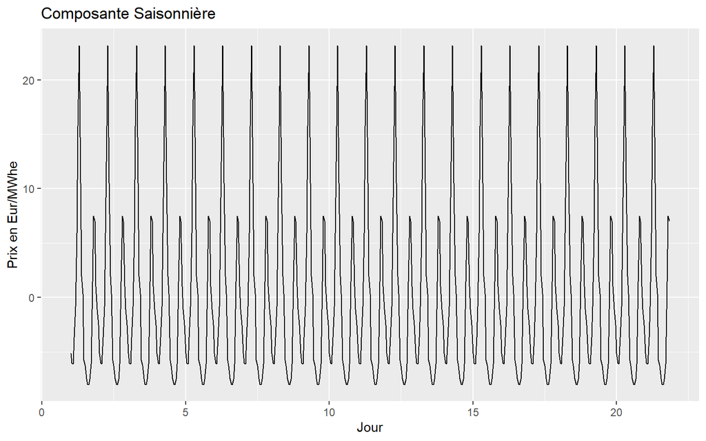

```r
df_seasonal <- data.frame(Date = time(m$seasonal), Prix = as.numeric(m$seasonal))
ggplot(df_seasonal, aes(x = Date, y = Prix)) +
  geom_line() +
  labs(title = "Composante Saisonnière", y = "Prix en Eur/MWhe", x = "Jour")
```

J’ai refait le même processus pour un autre moment de la serie temporelle, la saisonnalitée est la même tandis que la tendance a changée, elle varie beaucoup plus.

On peut avoir un lissage par moyenne mobile pour obtenir une estimation de la tendance.

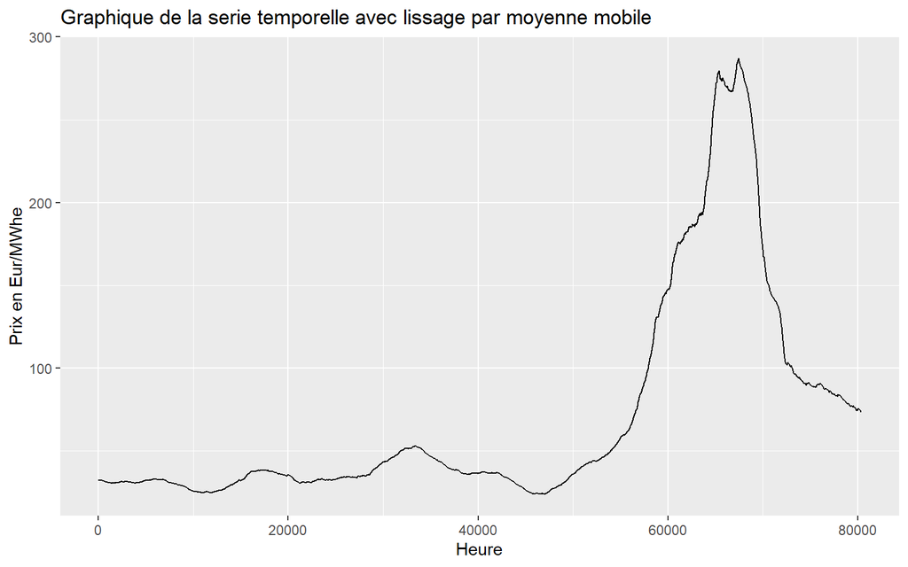

```r
smoothed_data = c()
k = c()
h = 5000   #taille de la fenetre
for (i in 1:length(df$Prix)){
  begin =max(1, i - h/2)
  end = min(length(df$Prix), i+h/2)
  smoothed_data[i] = mean(df$Prix[begin:end])
  k[i]= i
}

dfs <- data.frame(x = k, y = smoothed_data)


ggplot(dfs, aes(x = k, y = smoothed_data)) +
  geom_line() +
  labs(title = "Graphique de la serie temporelle avec lissage par moyenne mobile", y = "Prix en Eur/MWhe", x = "Heure")
```

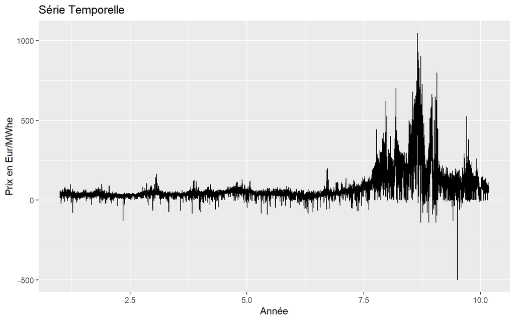

```r
Xh = ts(data = df$Prix, frequency = 24*365)
df3 <- data.frame(Date = time(Xh), Prix = as.numeric(Xh))
m = decompose(Xh)

ggplot(df3, aes(x = Date, y = Prix)) +
  geom_line() +
  labs(title = "Série Temporelle", y = "Prix en Eur/MWhe", x = "Année")
```

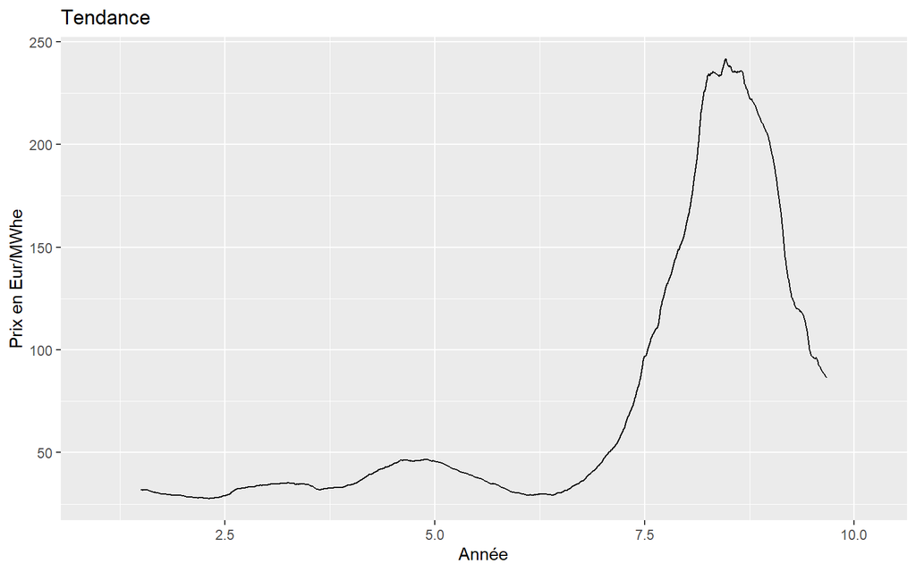

```r
df_trend <- data.frame(Date = time(m$trend), Prix = as.numeric(m$trend))
ggplot(df_trend, aes(x = Date, y = Prix)) +
  geom_line() +
  labs(title = "Tendance", y = "Prix en Eur/MWhe", x = "Année")
```

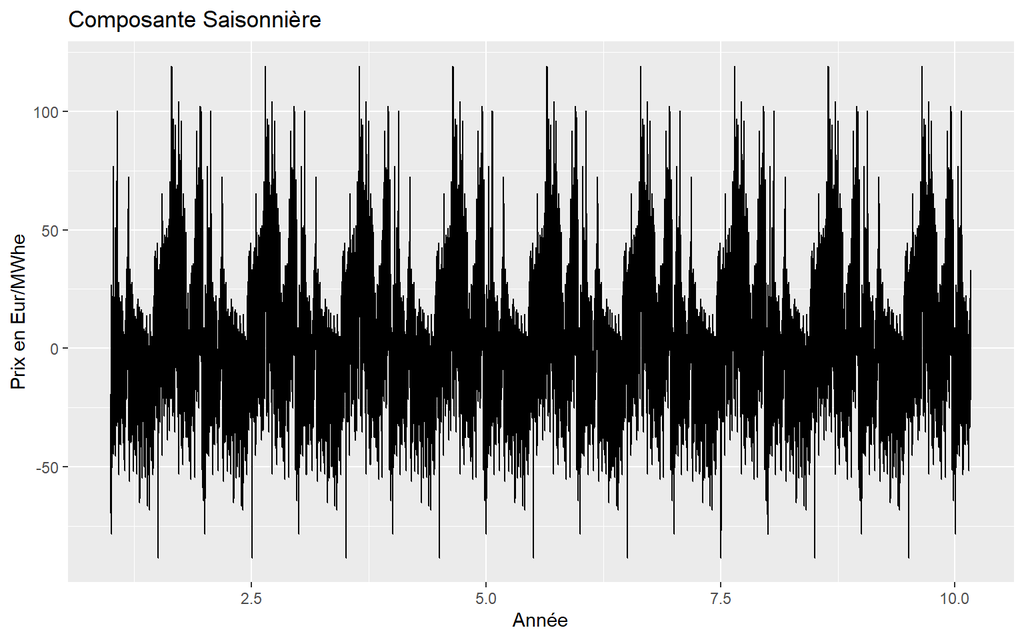

```r
df_seasonal <- data.frame(Date = time(m$seasonal), Prix = as.numeric(m$seasonal))
ggplot(df_seasonal, aes(x = Date, y = Prix)) +
  geom_line() +
  labs(title = "Composante Saisonnière", y = "Prix en Eur/MWhe", x = "Année")
```

Maintenant nous pouvons un peu comprendre ce qu’il se passe.

Ici je choisi une fréquence de $24\times 365$ afin que pour chaque numéro sur l’axe des abscisse représente une année

Comme je choisi une fréquence en année, on peut constater qu’il y a un cycle dans la composante saisonnière chaque année.

Pour la tendance elle est croissante puis décroissante.

Ici comme les variations dans la série sont plus grandes lorsque la série est à un niveau élevé et plus petites lorsque la série est à un niveau bas, alors je considère que ce modèle n’est ni additif ni multiplicatif. Cela revient à dire que ce modèle présente des aspects des deux modèle et donc que l’on peut essayer de modeliser ce modèle à l’aide d’un modele ARIMA.

C’est à dire que l’on ne peut pas reprsentée la série temporelle comme suit

$$Y_t = T_t + S_t + C_t + \varepsilon_t$$

ni comme suit :

$$Y_t = T_t \times S_t \times C_t \times \varepsilon_t$$

Avec :

- $Y_t$ est la valeur observée à un instant $t$.
- $T_t$ est la tendance à l’instant $t$.
- $S_t$ est la composante saisonnière à l’instant $t$.
- $C_t$ est la composante cyclique à l’instant $t$.
- $\varepsilon_t$ est le terme d’erreur aléatoire à l’instant $t$.

### Autocorrélogramme

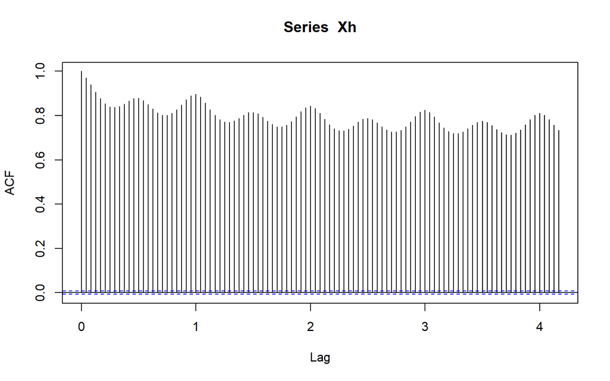

```r
Xh = ts(data = df$Prix, frequency = 24)
acf(Xh,lag.max=100)
```

La fonction d’autocorrélation est périodique, ce qui indique une périodicité dans la série temporelle. La ligne pointillée bleue indique le niveau en-dessous duquel la corrélation n’est plus statistiquement significative.

Le graphe des corrélations montre que les termes successifs de la suite sont très corrélés (et que donc il y a une tendance).

Les Lags sont toujours significatif.

De même les lags sont supérieur au trait bleu ce qui veut dire que ce n’est pas un bruit blanc

De même on peut interpréter une saisonnalité, on regarde à chaque fois que le lags est le plus haut et combien de lags après on retrouve un lags haut mais plus petit que le premier lag haut. Ici je trouve une périodicité de 24, ce qui correspond à 24h. Ca peut faire sens étant donné que c’est possible que la consommation d’électricité en une journée se repète.

```r
length(df$Prix)
```

```
## [1] 80328
```

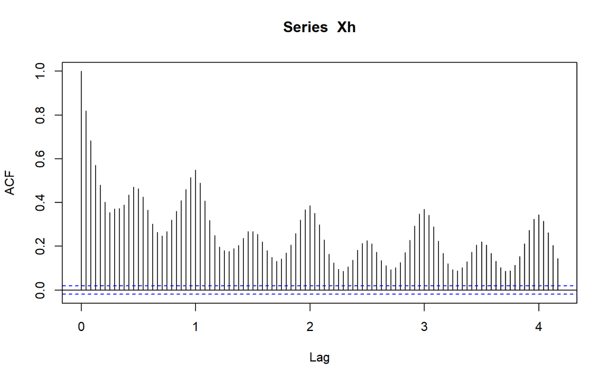

```r
Xh = ts(data = df$Prix[70000:80328], frequency = 24)
acf(Xh,lag.max=100)
```

Je me suis dit que ca pouvait être intéressant de regarder la fin de la série.

On voit qu’il y a la même chose.

Une périodiscitée tout les 24h et des lags que signficatifs.

### Autocorrélogramme partielle

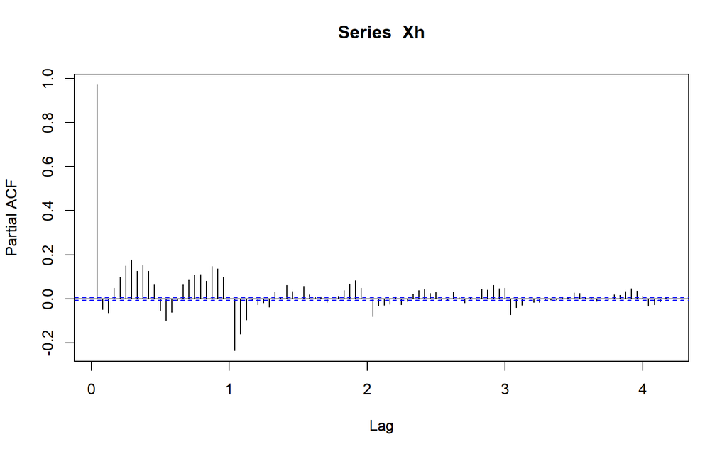

```r
Xh = ts(data = df$Prix, frequency = 24)
pacf(Xh,lag.max=100)
```

Ici on peut constater que les lags ne sont plus significatif de facon irrégulière, c’est donc difficile de déterminer quel modèle cette série temporelle suit.

### Test de stationnarité

Une série temporelle $Y_{t(t=1,2...)}$ est dite stationnaire (au sens faible) si ses propriétés statistiques ne varient pas dans le temps (espérance, variance, auto-corrélation).

Test de Dickey-Fuller Test

```r
library(tseries)
adf.test(df$Prix, alternative = c("sta"))
```

```
##
##  Augmented Dickey-Fuller Test
##
## data:  df$Prix
## Dickey-Fuller = -11.783, Lag order = 43, p-value = 0.01
## alternative hypothesis: stationary
```

$H_0$ : La série n’est pas stationnaire

$H_1$ : la série est stationnaire

p value = 0.01 $< \alpha$, on rejette $H_0$

On peut donc considérer statistiquement que cette série est stationnaire.

### Prédiction

Afin de faire la prédiction nous pouvons utiliser le modele exponentiel.

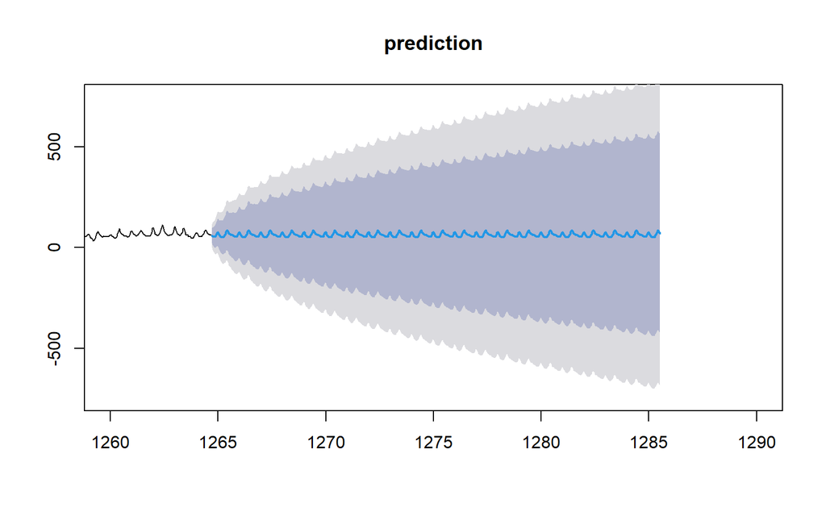

```r
library(forecast)

Xh = ts(data = df$Prix[50000:80328], frequency = 24)
model1 <- ets(Xh)


predictions1 <- forecast(model1, h = 500)


plot(predictions1, xlim = c(1260,1290), ylim = c(-750,750), main = "prediction")
```

Voici la prédiction de très près pour montrer qu’on voit les petites variations, si l’on zoom pas on peut penser que c’est une droite

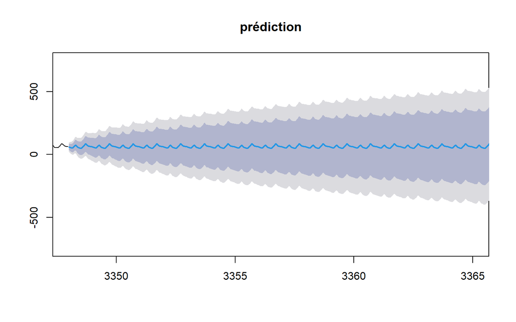

```r
library(forecast)


Xh = ts(data = df$Prix, frequency = 24)
model2 <- ets(Xh)


predictions2 <- forecast(model2, h = 500)


plot(predictions2, xlim = c(3348,3365),ylim = c(-750,750), main = "prédiction")
```

L’une en prenant les données de la fin et l’autre en prenant toute les données.

```r
summary(model1)
```

```
## ETS(A,N,A)
##
## Call:
##  ets(y = Xh)
##
##   Smoothing parameters:
##     alpha = 0.5841
##     gamma = 0.1271
##
##   Initial states:
##     l = 64.1291
##     s = 24.1406 10.8229 -10.48 -26.7748 -28.4873 -26.3296
##            -22.6495 -18.3514 -10.3038 4.9791 17.6824 28.7163 42.5338 47.0006 30.1299 5.1888 -11.8213 -18.8609 -21.4704 -19.9282 -13.3775 -2.7004 6.8884 13.4519
##
##   sigma:  29.2045
##
##      AIC     AICc      BIC
## 517698.8 517698.8 517923.4
##
## Training set error measures:
##                         ME     RMSE      MAE MPE MAPE      MASE      ACF1
## Training set -3.454868e-05 29.19203 15.34582 NaN  Inf 0.4239708 0.1688478
```

```r
summary(model2)
```

```
## ETS(A,N,A)
##
## Call:
##  ets(y = Xh)
##
##   Smoothing parameters:
##     alpha = 0.6016
##     gamma = 0.1282
##
##   Initial states:
##     l = 35.8421
##     s = -11.491 -7.268 0.7958 7.9864 14.3096 22.3787
##            25.0487 16.7858 4.2418 -4.8646 -9.3703 -9.5449 -7.8147 -4.5648 0.6414 4.8011 10.8682 12.9337 4.8825 -6.3075 -15.2906 -16.6974 -15.8505 -16.6094
##
##   sigma:  18.298
##
##     AIC    AICc     BIC
## 1374236 1374236 1374487
##
## Training set error measures:
##                        ME     RMSE      MAE MPE MAPE      MASE      ACF1
## Training set 0.0005512238 18.29502 7.671721 NaN  Inf 0.4001011 0.1682045
```

Le BIC du premier modele est plus faible donc on peut se fier à celui là.

Une critique de ce modèle est de constater que c’est une prédiction à très court terme, néanmoins l’avantage étant qu’il fonctionne facilement car il n’y a pas d’hypothèses à respecter afin de l’appliquer

## Etude par jour

Afin de faciliter le traitement des données je décide de mettre les données par jours

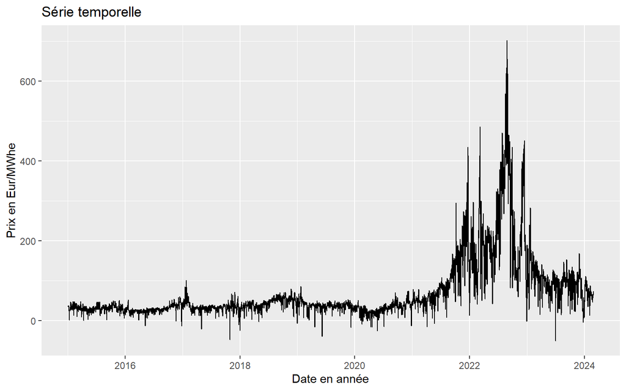

```r
library(tidyverse)
library(Ecdat)

dfj = df %>%
  mutate(datm = as.Date(heuremond))  %>%
  group_by(datm) %>%
  summarise(Prixm = mean(Prix), .groups = "drop")


library(forecast)


library(ggplot2)


# Créer le graphique avec ggplot
ggplot(data = dfj, aes(x = datm, y = Prixm)) +
  geom_line() +
  labs(x = "Date en année", y = "Prix en Eur/MWhe", title = "Série temporelle")
```

### Tendance et saisonnalité

Je vais refaire certaine étape afin de m’assurer des hypothèses que j’ai dite pour mon étude sur les heures.

Je fais un lissage par moyenne mobile.

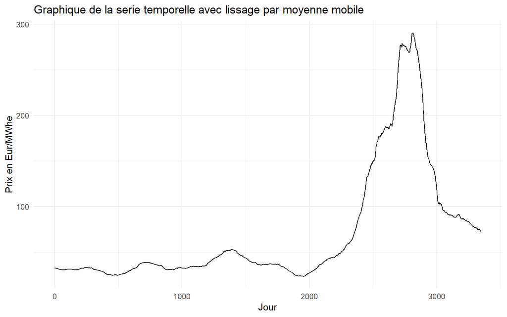

```r
smoothed_data = c()
k = c()
h = 200   #taille de la fenetre
for (i in 1:length(dfj$Prixm)){
  begin =max(1, i - h/2)
  end = min(length(dfj$Prixm), i+h/2)
  smoothed_data[i] = mean(dfj$Prixm[begin:end])
  k[i]= i
}

dfs <- data.frame(x = k, y = smoothed_data)


ggplot(dfs, aes(x = k, y = smoothed_data)) +
  geom_line() +
  labs(title = "Graphique de la serie temporelle avec lissage par moyenne mobile", y = "Prix en Eur/MWhe", x = "Jour") +
  theme_minimal()
```

On retrouve le même lissage que précedemment.

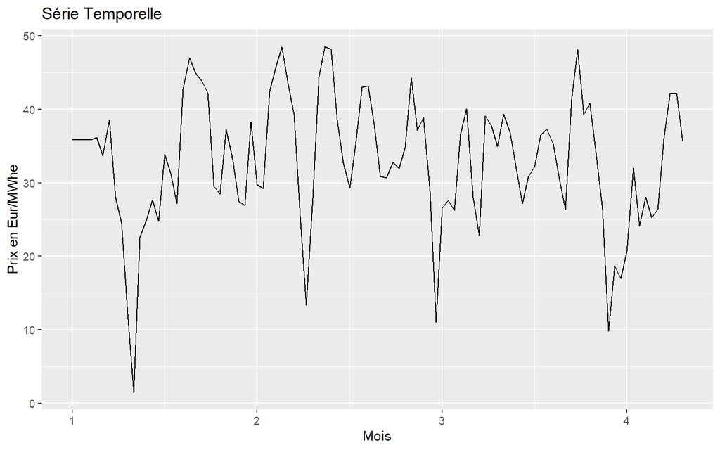

```r
X = ts(data = dfj$Prixm[1:100], frequency = 30)
m = decompose(X)

df1 <- data.frame(Date = time(X), Prix = as.numeric(X))

ggplot(df1, aes(x = Date, y = Prix)) +
  geom_line() +
  labs(title = "Série Temporelle", x = "Mois", y ="Prix en Eur/MWhe")
```

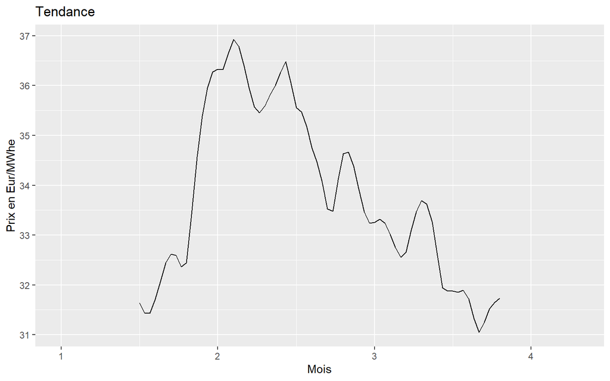

```r
df_trend <- data.frame(Date = time(m$trend), Prix = as.numeric(m$trend))
ggplot(df_trend, aes(x =Date, y = Prix)) +
  geom_line() +
  labs(title = "Tendance", x = "Mois", y ="Prix en Eur/MWhe")
```

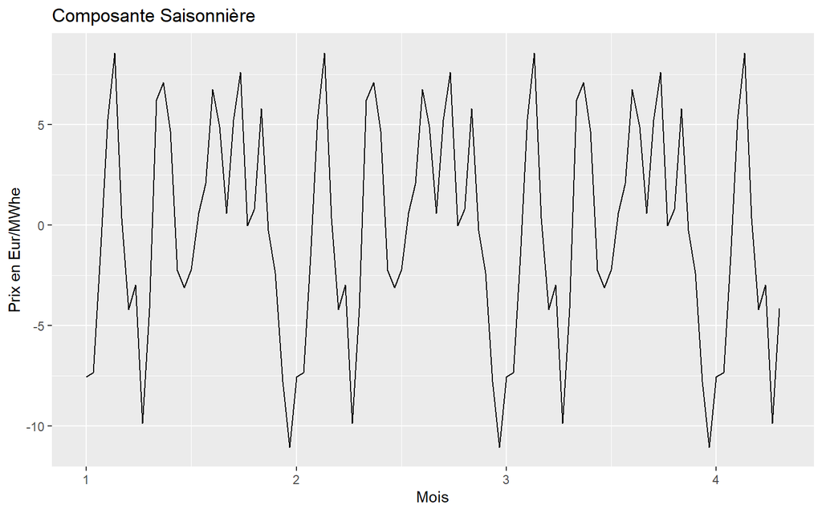

```r
df_seasonal <- data.frame(Date = time(m$seasonal), Prix = as.numeric(m$seasonal))
ggplot(df_seasonal, aes(x = Date, y = Prix)) +
  geom_line() +
  labs(title = "Composante Saisonnière", x = "Mois", y ="Prix en Eur/MWhe")
```

Pour cette partir on voit une tendance croissante puis décroissante, pour la saisonnalité, on voit que le cycle de variation se répete tout les mois, ce qui fait sens car si tout les 24h il y a une périodiscité, il en va de même pour les mois.

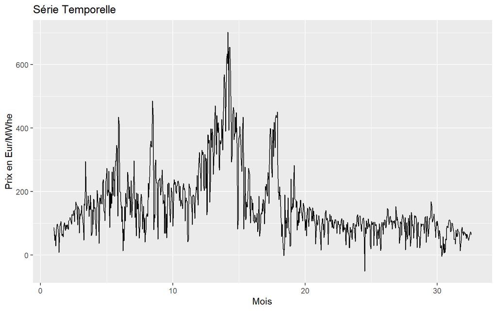

```r
X = ts(data = dfj$Prixm[2400:3347], frequency = 30)
m = decompose(X)

df1 <- data.frame(Date = time(X), Prix = as.numeric(X))

ggplot(df1, aes(x = Date, y = Prix)) +
  geom_line() +
  labs(title = "Série Temporelle", x = "Mois", y ="Prix en Eur/MWhe")
```

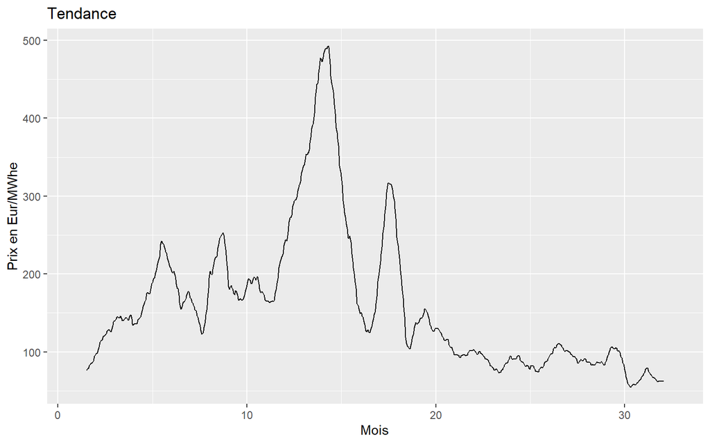

```r
df_trend <- data.frame(Date = time(m$trend), Prix = as.numeric(m$trend))
ggplot(df_trend, aes(x =Date, y = Prix)) +
  geom_line() +
  labs(title = "Tendance", x = "Mois", y ="Prix en Eur/MWhe")
```

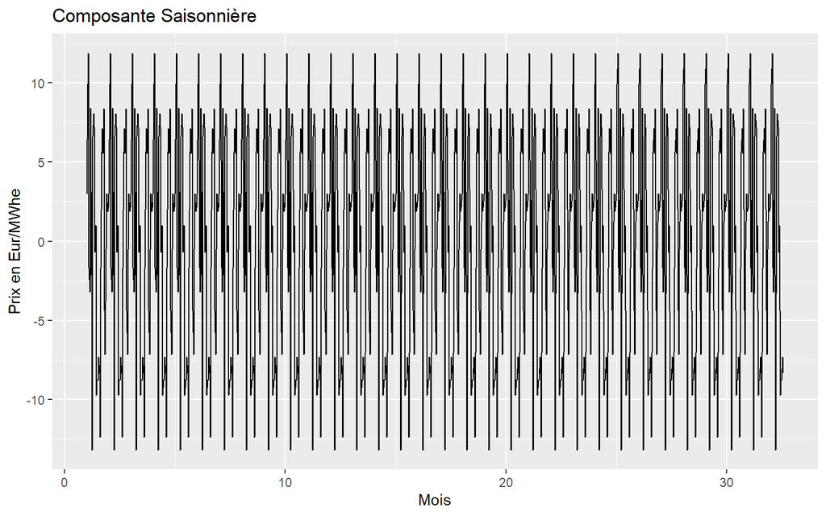

```r
df_seasonal <- data.frame(Date = time(m$seasonal), Prix = as.numeric(m$seasonal))
ggplot(df_seasonal, aes(x = Date, y = Prix)) +
  geom_line() +
  labs(title = "Composante Saisonnière", x = "Mois", y ="Prix en Eur/MWhe")
```

J’ai regardé la tendance et la saisonnalité sur la partie où les prix sont élevé sur la série temporelle et on constate qu’il y a bien une saisonnalitée au mois et que la tendance varie énormement, elle est croissante puis décroissante.

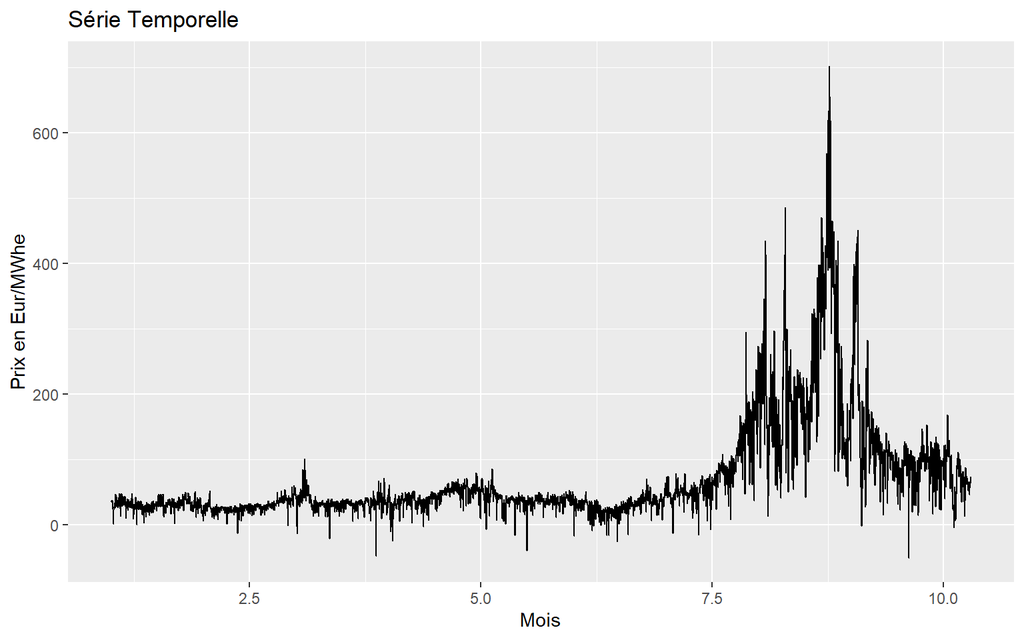

```r
Xj = ts(data = dfj$Prixm, frequency = 30*12)
df2 <- data.frame(Date = time(Xj), Prix = as.numeric(Xj))
m = decompose(Xj)
ggplot(df2, aes(x = Date, y = Prix)) +
  geom_line() +
  labs(title = "Série Temporelle", x = "Mois", y ="Prix en Eur/MWhe")
```

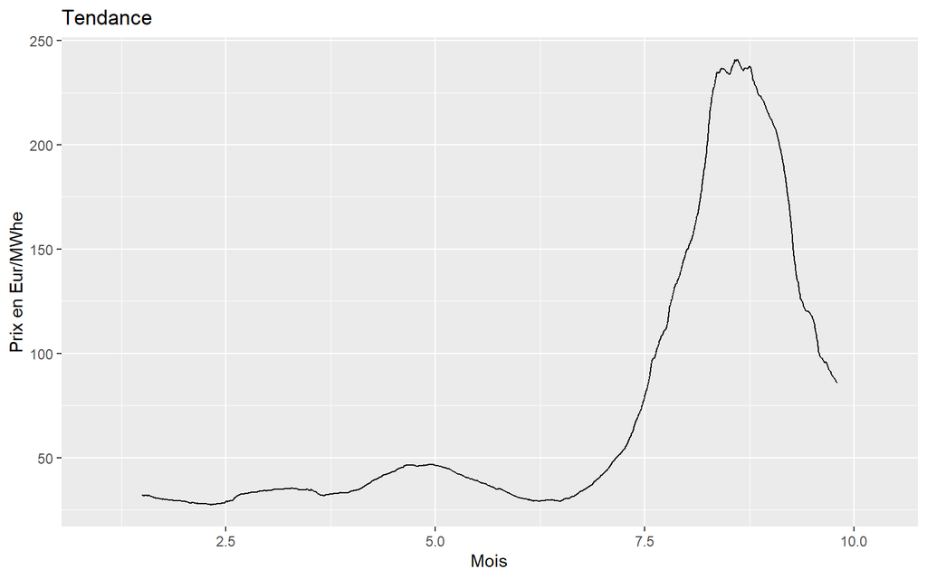

```r
df_trend <- data.frame(Date = time(m$trend), Prix = as.numeric(m$trend))
ggplot(df_trend, aes(x =Date, y = Prix)) +
  geom_line() +
  labs(title = "Tendance", x = "Mois", y ="Prix en Eur/MWhe")
```

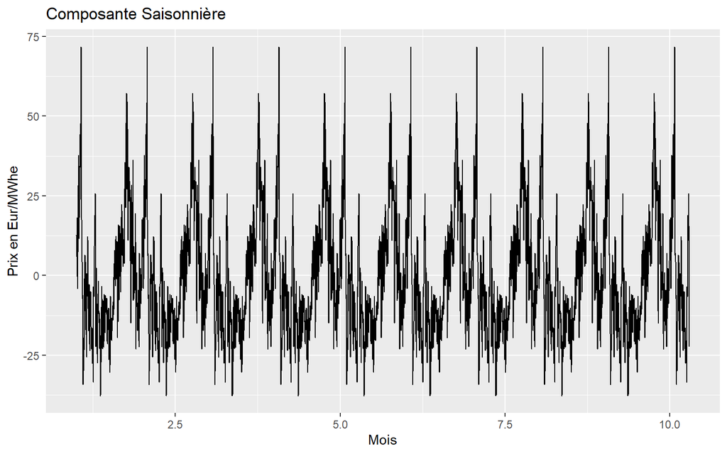

```r
df_seasonal <- data.frame(Date = time(m$seasonal), Prix = as.numeric(m$seasonal))
ggplot(df_seasonal, aes(x = Date, y = Prix)) +
  geom_line() +
  labs(title = "Composante Saisonnière", x = "Mois", y ="Prix en Eur/MWhe")
```

Maintenant nous pouvons un peut comprendre ce qu’il se passe

Pour la saisonnalité c’est la même chose, le variations se reproduise.

### Autocoréllogramme

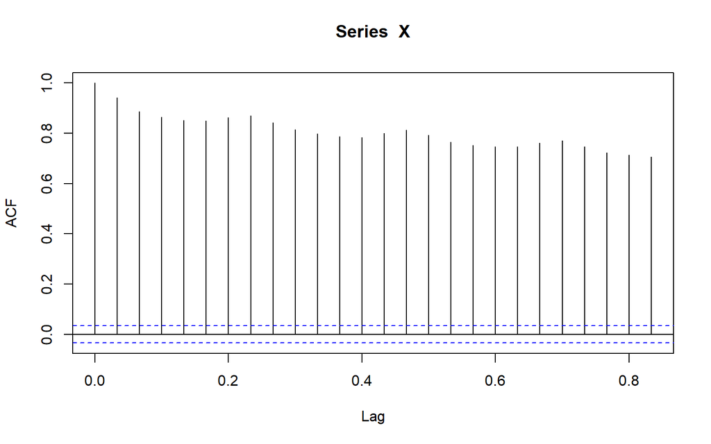

```r
X = ts(data = dfj$Prixm, frequency = 30)
acf(X,lag.max=25)
```

La fonction d’autocorrélation est périodique, ce qui indique une périodicité dans la série temporelle. La ligne pointillée bleue indique le niveau en-dessous duquel la corrélation n’est plus statistiquement significative.

De même les lags sont supérieur au trait bleu ce qui veut dire que ce n’est pas un bruit blanc

### Autocorrélogramme partielle

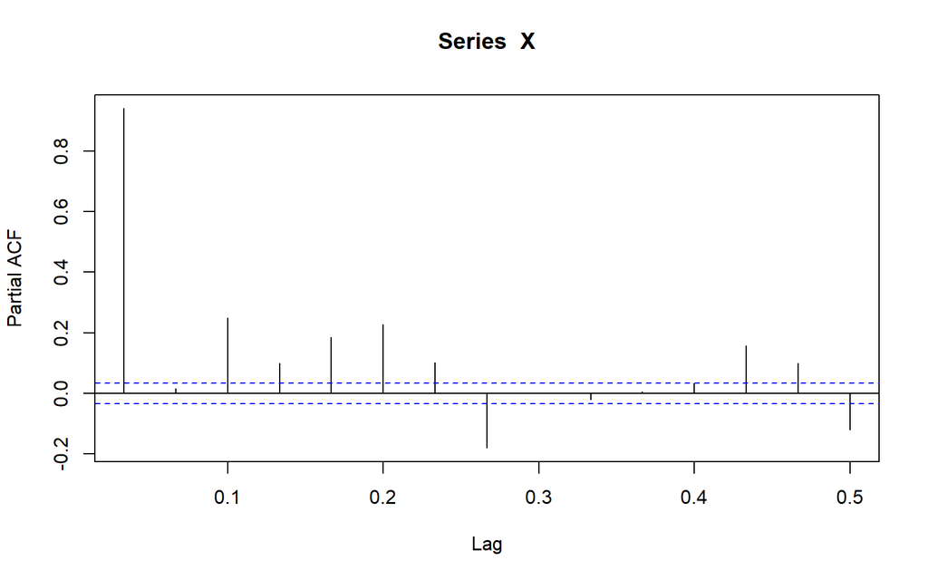

```r
pacf(X,lag.max=15)
```

### Test de stationnarité

Une série temporelle Yt (t=1,2...) est dite stationnaire (au sens faible) si ses propriétés statistiques ne varient pas dans le temps (espérance, variance, auto-corrélation). Un exemple de série temporaire stationnaire est le bruit blanc.

Test de Dickey-Fuller Test

```r
library(tseries)
adf.test(X, alternative = c("sta"))
```

```
##
##  Augmented Dickey-Fuller Test
##
## data:  X
## Dickey-Fuller = -4.619, Lag order = 14, p-value = 0.01
## alternative hypothesis: stationary
```

$H_0$ : La série n’est pas stationnaire

$H_1$ : la série est stationnaire

On choisi un seuil $\alpha$ a 5%

p value < $\alpha$, on rejette $H_0$

# Prédiction

Je souhaite faire une pérdiction pour l’année 2024, à l’aide de mes données par jours. Afin d’avoir des prédiction par mois, je choisi de mettre une fréquence par 30 jours soit en mois.

```r
length(dfj$Prixm)
```

```
## [1] 3347
```

```r
Xj = ts(dfj$Prixm, frequency= 30)

sarima_model <-  arima(Xj, order = c(3, 1, 3), seasonal = list(order = c(0, 0, 1), period = 30))
```

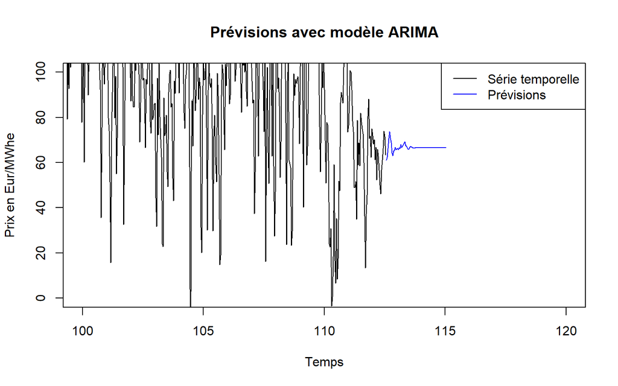

```r
library(forecast)
predictions <- predict(sarima_model, n.ahead = 75)

plot(Xj, xlim = c(100,120),ylim = c(0,100),
     xlab = "Temps", ylab = "Prix en Eur/MWhe", main = "Prévisions avec modèle ARIMA")
lines(predictions$pred, col = "blue")
legend("topright", legend = c("Série temporelle", "Prévisions"), col = c("black", "blue"), lty = 1)
```

```r
print(predictions$pred)
```

```
## Time Series:
## Start = c(112, 18)
## End = c(115, 2)
## Frequency = 30
##  [1] 61.04896 62.27711 66.20197 70.65967 73.75705 70.83239 68.93438 64.28453
##  [9] 63.09425 65.15227 65.34044 66.72213 65.78492 66.03808 66.19814 65.77551
## [17] 66.67272 66.20251 67.98234 66.66054 67.27820 67.93779 68.65390 69.25719
## [25] 67.55738 67.27258 66.66090 65.96201 65.90167 66.86245 67.15375 67.00380
## [33] 66.73242 66.47730 66.40485 66.44524 66.55876 66.63571 66.66853 66.64420
## [41] 66.60961 66.57773 66.57118 66.57723 66.59238 66.60134 66.60504 66.60125
## [49] 66.59692 66.59293 66.59246 66.59331 66.59534 66.59635 66.59677 66.59619
## [57] 66.59567 66.59516 66.59515 66.59527 66.59554 66.59565 66.59570 66.59561
## [65] 66.59555 66.59548 66.59549 66.59550 66.59554 66.59555 66.59556 66.59554
## [73] 66.59554 66.59553 66.59553
```

Voici une prédiction par jour, le modèle est assez précis mais ne va pas très loin dans le temps.

## Prédiction par Mois

```r
dfj$Mois <- format(dfj$datm,"%Y-%m")

dfm = dfj %>% group_by(Mois) %>%
  summarise(Prixmm = mean(Prixm), .groups = "drop")

arima_model <-  arima(dfm$Prixmm, order = c(0, 1, 2))
predictions <- predict(arima_model, n.ahead = 2)

print(predictions$pred)
```

```
## Time Series:
## Start = 111
## End = 112
## Frequency = 1
## [1] 58.21125 67.12545
```

Voici la prédiction en mois.

## Prédiction en année

```r
dfj$Annee <- format(dfj$datm,"%Y")

dfa1 = dfj %>% group_by(Annee) %>%
  summarise(Prixmm = mean(Prixm), .groups = "drop")

dfa = dfa1 %>% filter(Annee != 2024)

library(forecast)
sarima_model <- auto.arima(dfa$Prixmm)
model= ets(dfa$Prixmm)
forecast_result <- forecast(model)
print(forecast_result$mean[1])
```

```
## [1] 96.68879
```

Voici la prediction de l’année 2024 en ce basant sur les années d’avant.

En somme on peut faire des prédictions sur l’année mais elle sera moins précise que celle par jour par exemple mais qui va pas loin, il faut aussi prendre en compte qu’on se base sur des moyenne ce qui rend la chose moins précise.